# Data Visualization

Prosper is a P2P lending platform that allows investors to choose among personal loans to invest in. They do that by considering a number of factors, which include a custom calculated Prosper Score that represents the risk for each loan. The higher the score, the lower the risk, and the lower the interest rates paid by the borrower to the investors.

## Univariate Exploration

I will start by looking at the main variable of interest: `BorrowerRate`.

### Income Range:

The income range of the borrower at the time the listing was created.

Does Prosper give out with income as part of their consideration?

The plot shows that most individual who has a loan has an income range from 25k to 75k. However, this plot cannot find any trend related to the amount of income against getting a loan. This plot simply reflects the distribution of income range for people who can obtain a loan.

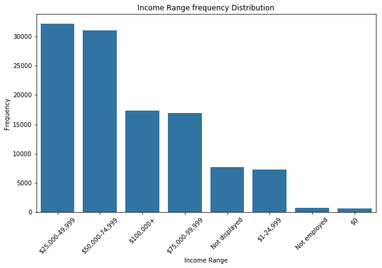

```python
plt.figure(figsize=[10, 6]);
sb.countplot(data = df, x = 'IncomeRange', color = colorChoice);
plt.title('Income Range frequency Distribution');
plt.ylabel('Frequency');
plt.xlabel('Income Range');
plt.xticks(rotation=45);
```

### BorrowerRate:

The Borrower's interest rate for this loan.

What is the borrower's APR for people who has a loan?

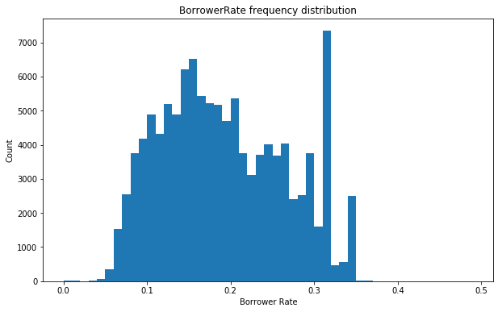

```python
plt.figure(figsize=[10, 6]);
b = np.arange(0,df['BorrowerRate'].value_counts().index.max(),0.01)
plt.hist(data = df, x = 'BorrowerRate', bins = b);

plt.title('BorrowerRate frequency distribution');
plt.xlabel('Borrower Rate');
plt.ylabel('Count');
```

### Occupation

The Occupation selected by the Borrower at the time they created the listing.

What is the occupation distribution of borrower?

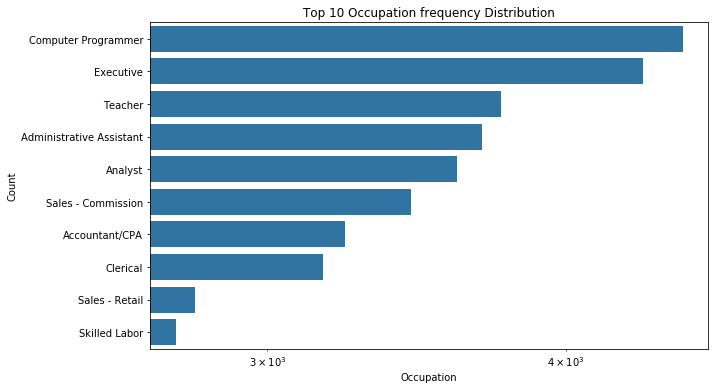

```python
plt.figure(figsize=[10, 6]);
top_ten_occupation = ['Computer Programmer','Executive','Teacher','Administrative Assistant','Analyst','Sales - Commission','Accountant/CPA','Clerical','Sales - Retail','Skilled Labor']
occupation_sub = df.loc[df['Occupation'].isin(top_ten_occupation)]

sb.countplot(data = occupation_sub, y = 'Occupation', color = colorChoice, order = occupation_sub['Occupation'].value_counts().index);
plt.title('Top 10 Occupation frequency Distribution');
plt.ylabel('Count');
plt.xlabel('Occupation');
plt.xscale('log');
```

## Bivariate Exploration

### Occupation against borrower's rate

Does occupation affect a borrower's rate?

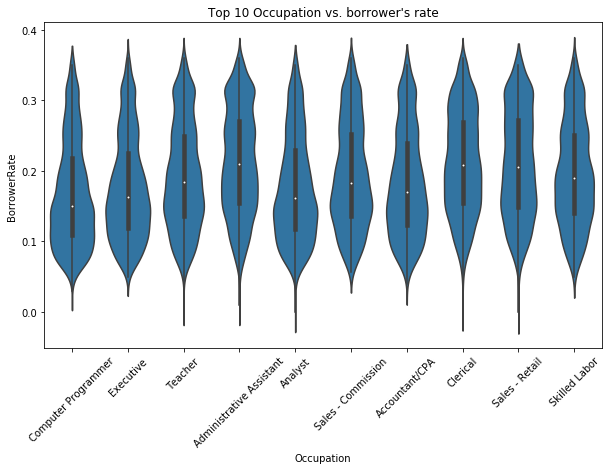

```python
plt.figure(figsize=[10, 6]);
sb.violinplot(data = df, x = 'Occupation', y = 'BorrowerRate', color=colorChoice, order = occupation_sub['Occupation'].value_counts().index);
plt.xticks(rotation = '90');
plt.title('Top 10 Occupation vs. borrower\'s rate');
plt.xticks(rotation=45);
```

### Yearly Borrower Rates

What is the yearly trend of borrower rates?

It is interesting to see that rate goes high up after 2008 until 2011. And since then, the rate is steadily come down until 2014.

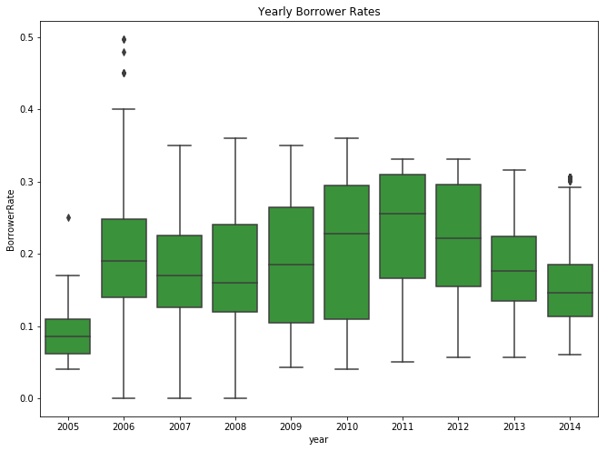

```python
plt.figure(figsize=[11, 8]);
base_color = sb.color_palette()[2];
sb.boxplot(data = df, x = 'year', y = 'BorrowerRate', color = base_color);
plt.title('Yearly Borrower Rates');
```

### Borrower rates vs. ProsperScore

Is rate determined by ProsperScore?

This plot shows a strong indication that the score is a good determinating factor of borrower's rate. We see that the higher the score, the lower the rate.

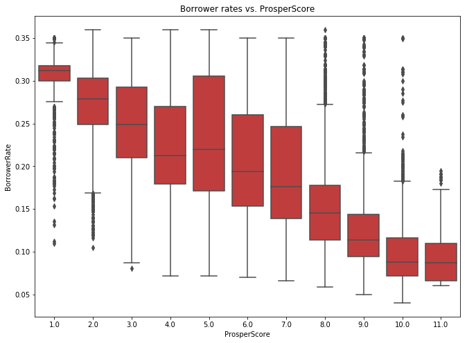

```python
plt.figure(figsize=[11, 8]);
base_color = sb.color_palette()[3];
sb.boxplot(data = df, x = 'ProsperScore', y = 'BorrowerRate', color = base_color);
plt.title('Borrower rates vs. ProsperScore');
```

## Multivariate Exploration

### Yearly Borrower rate vs. isHomeOwner

Does being a homeowner affect borrower rate?

According to the plot, it does seem like homeowners have a slightly lower rate that non-homeowners.

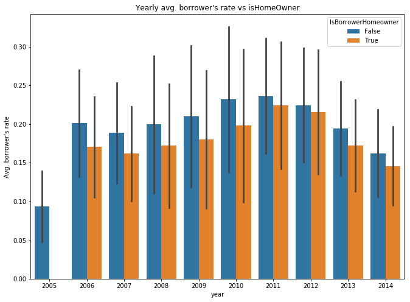

```python
plt.figure(figsize=[11, 8]);
sb.barplot(data = df, x = 'year', y = 'BorrowerRate', hue = 'IsBorrowerHomeowner', ci = 'sd');
plt.ylabel('Avg. borrower\'s rate');
plt.title('Yearly avg. borrower\'s rate vs isHomeOwner');
```

### Year borrower's rate vs. ProsperScore vs. isHomeOwner

Does yearly prosperScore and homeowner affect borrower's rate?

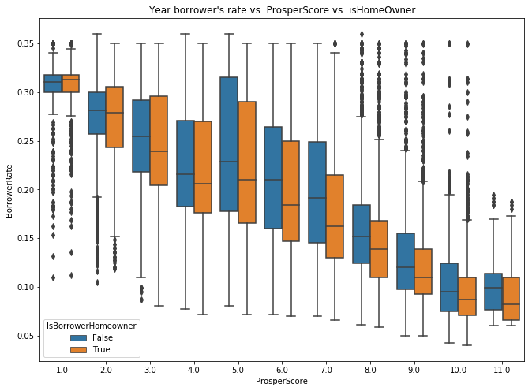

```python
plt.figure(figsize=[11, 8]);
sb.boxplot(data = df, x = 'ProsperScore', y = 'BorrowerRate', hue = 'IsBorrowerHomeowner');
plt.title('Year borrower\'s rate vs. ProsperScore vs. isHomeOwner');
```

### Year borrower's rate vs. ProsperScore vs. IncomeRange

Does Income range and prosperscore affect borrower's rate?

[figure not shown]

```python
plt.figure(figsize=[10, 6]);
income_range_valid = ['$25,000-49,999','$50,000-74,999','$100,000+','$75,000-99,999','$1-24,999']
income_range_sub = df.loc[df['IncomeRange'].isin(income_range_valid)]

sb.barplot(data = income_range_sub, x = 'ProsperScore', y = 'BorrowerRate', hue = 'IncomeRange');
plt.title('Year borrower\'s rate vs. ProsperScore vs. valid IncomeRange');
```